# computeTimes

2022-07-31

## Load packages and data

```r
library(tidyverse)
library(janitor)
```

## Computation times to run neural networks of different sizes

Neural network inference computation is the act of runing a neural network on an input to create an output. In our case, the input to the network is an image, and the output is a list of detected objects and where they were found in the image.

We collected data for running neural network inference computations over a variety of variables in order to determine how the variables affected the speed.

Variables of interest:

- Model: What model and size of model was used
- gpu: Was computation done on gpu or not (if not then it is on a CPU)
- network: Were images sent over a network, and if so was it wired or wireless
- images: number of images in the test
- time: in seconds to run all the images
- fps: Frames per second, calculated by dividing images / time.

First, we read in the data and look at it.

```r
# remove rows where model is NA.
inference <- read_csv(file = "data/neuralnetworkspeed.csv", skip_empty_rows = TRUE) %>%
  filter(!is.na(model)) %>%
  clean_names()
```

## Plot fps (speed) vs. model

We are interested to understand how different variables affect speed. Let’s look at fps vs. model and gpu

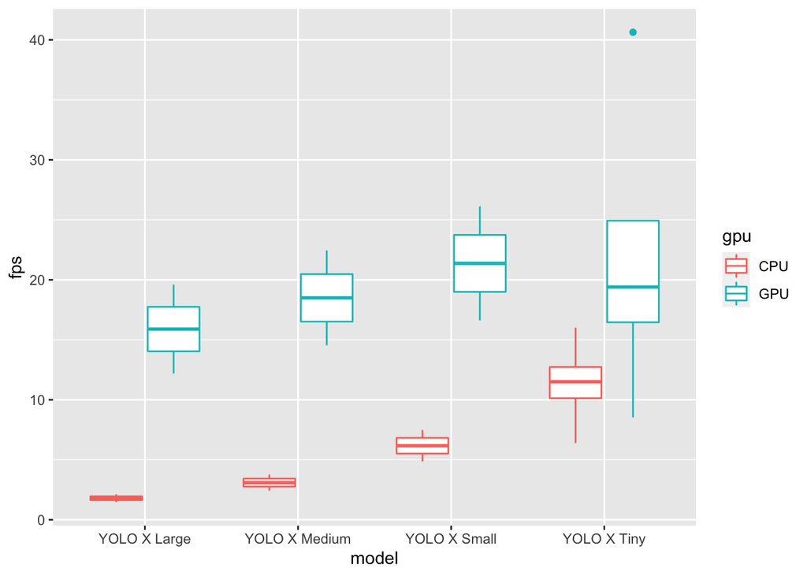

Let’s also look at fps vs. model and network settings

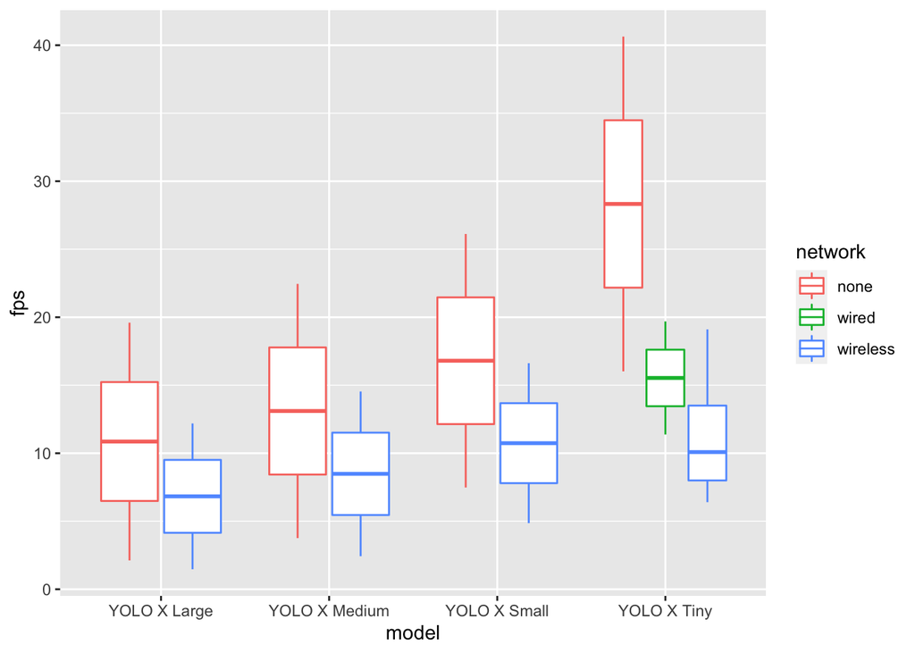

### gpu is faster

It is clear that running the inference on gpu is faster than running on CPU. But there is still a large variation in some data. Let’s dig into just the gpu data.

This is a good plot, but I wish I had an interactive way to visualize the plots so I can see what I want to see.

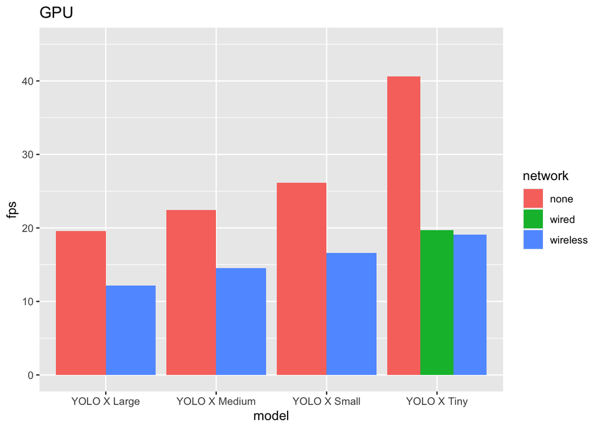

```r
theGPUfilter <- "GPU"
theNetworkFilter <- c("none","wireless","wired")
inference %>%
  filter(gpu %in% theGPUfilter,
         network %in% theNetworkFilter) %>%
  ggplot(aes(x = model, y = fps, fill = network)) +
  geom_col(position="dodge") +
  labs(title = theGPUfilter) +
      ylim(0,45)
```